# Wrangle Report

```
                                                                                     David Ugochukwu Asogwa
                                                                                     June 25, 2022
                                                                                     Udacity Data Analytics Nanodegree
```

The wrangling process started by importing the needed packages into the jupyter workspace. These packages included but not limited to `pandas` (for reading files), `numpy` (for mathematical operations), `json`, `matplotlib` and `os`.

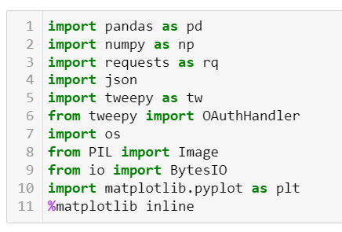

Importing packages

Twitter developer account was needed in order to gather the remaining files required to complete the wrangling process. Though these data have been provided already, but for knowledge sake, the developer account was created. Approval was immediate, but getting acquainted with the developer account interface, creating projects and apps, getting the needed access keys and secrets took a while. The twitter `API` was then querried and neccessary data collected. The querrying process took a while to complete due to the `wait_on_rate_limit` and some syntax error that were dealt with.

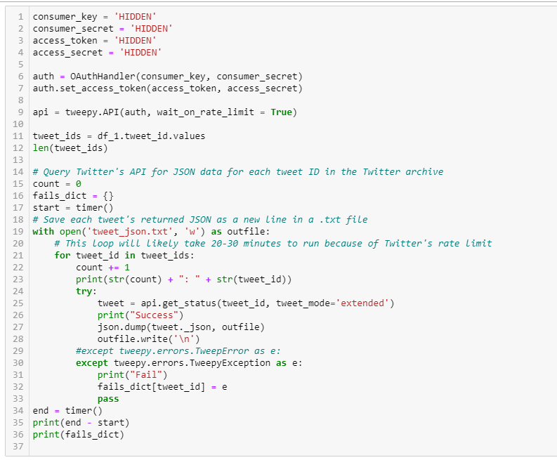

Querrying Twitter API

After the data gathering, they were loaded into the jupyter workspace and were accessed both manually and programmatically, especially the JSON file. The manual assessment was a bit tedius as it involved looking through the files to understand their arangement, check for errors in the data and detect issues. The programmatic assessment was way easier as it displays data that gives immediate insight on which issues the particular dataset has, from which a solution will be proposed. The programmatic assessment was carried out using functions as `df.head`, `df.info()`, and `df.sample(5)`. It is through this assessment that issues are detected and then outlined for cleaning.

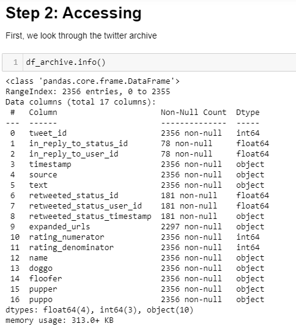

Assesing data

There were issues detected during this assessment stage, and were documented under the categories: quality issues and tidiness issues as shown below. These issues were later tackled during the cleaning stage.

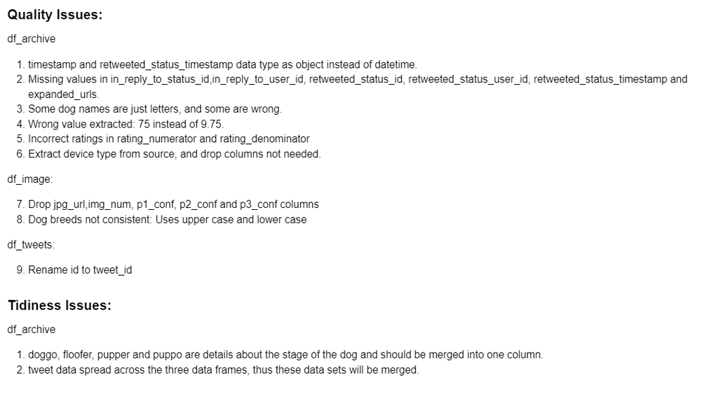

Issues detected

The cleaning stage takes the bulk of the work in the data wrangling process. This is because all the issues outlined during the assessment stage have to be cleaned/resolved in the most efficient manner, then making a choice or finding the appropriate method to use also becomes a problem. Different pandas functions were used in the cleaning process. These include but not limited to `loc`, `split`, `copy()`, `datetime`, `info()` and `describe()`. `Functions` and `if-else` statements were also used to make the process easy and avoid code repetition.

Cleaning the issues took the following approach:

1. `define`: a process to solve the problem is writen down

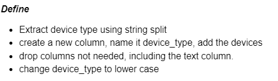

2. `code`: write a code to solve the problem

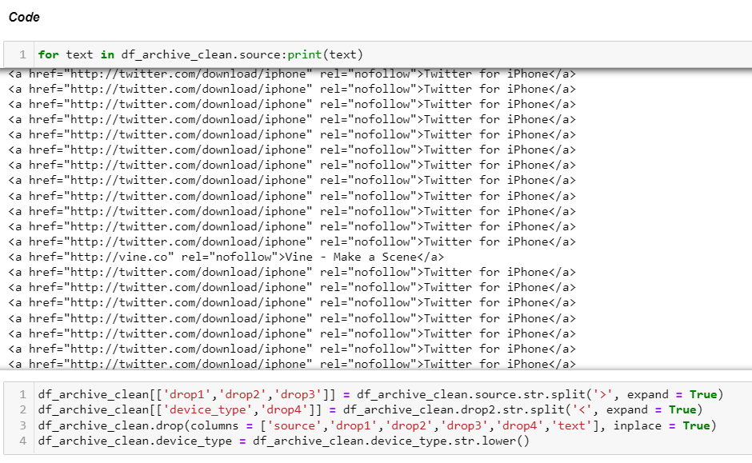

3. `test`: check if the code worked and the problem is solved.

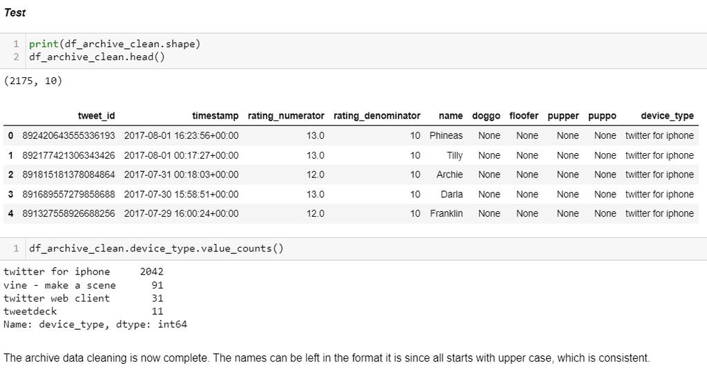

In the actual sense, the cleaning process is an `iterative process` that revolved around the three approaches above. The cleaning was done, which involed `dropping some columns not needed`, `merging files`, `data type conversion`, `dropping NaN rows` and `replacing some values with the column mean`.

When the cleaning was done, the final dataset was saved as a master dataset with the name `twitter_archive_master.csv`.

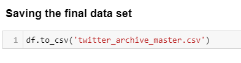

Visualizations and insights were drawn from the data as shown below:

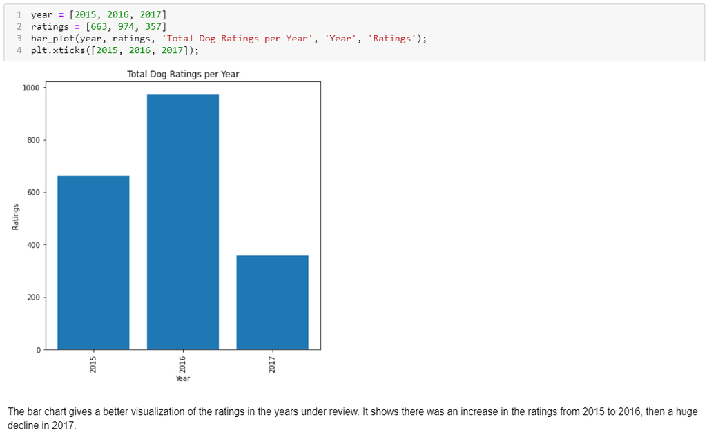